# Group Project - STAT1261

Mahima Sindhu

11/22/2020

```r
library(tidyr)
library(dplyr)
library(atus)
data("atuscps")
tibble1 <- as_tibble(atuscps) %>%
  na.omit()
```

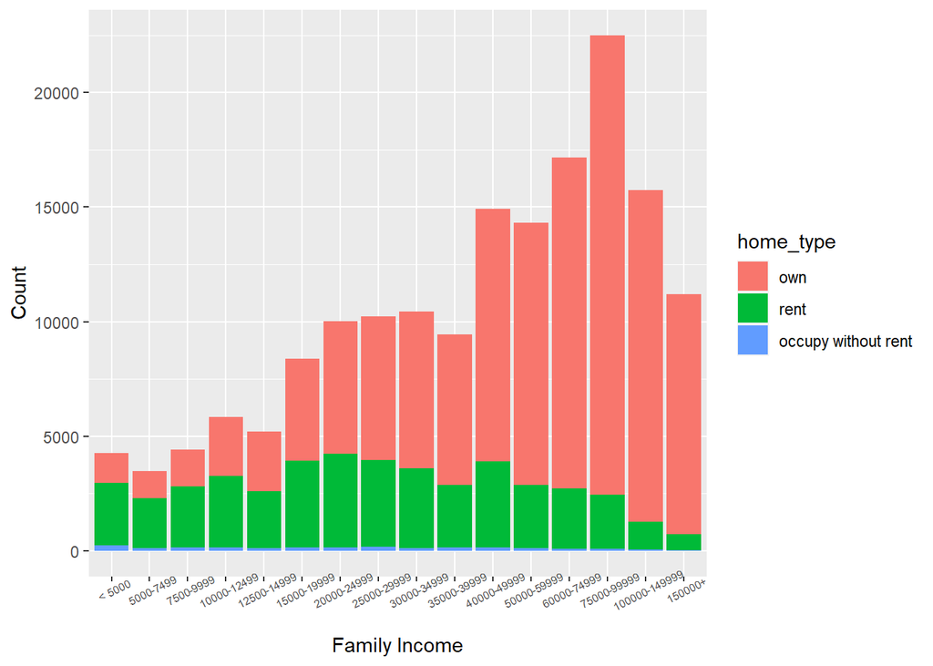

```r
library(ggplot2)
library(RColorBrewer)
tibble1 <- as_tibble(atuscps) %>%
  na.omit()

plotcps <- ggplot(data=tibble1) +
  geom_bar(mapping=aes(x=famincome, fill=home_type)) +
  xlab("Family Income") +
  ylab("Count") +
  scale_color_brewer("Set1")

plotcps + theme(axis.text.x = element_text(angle = 27, size = 6))
```

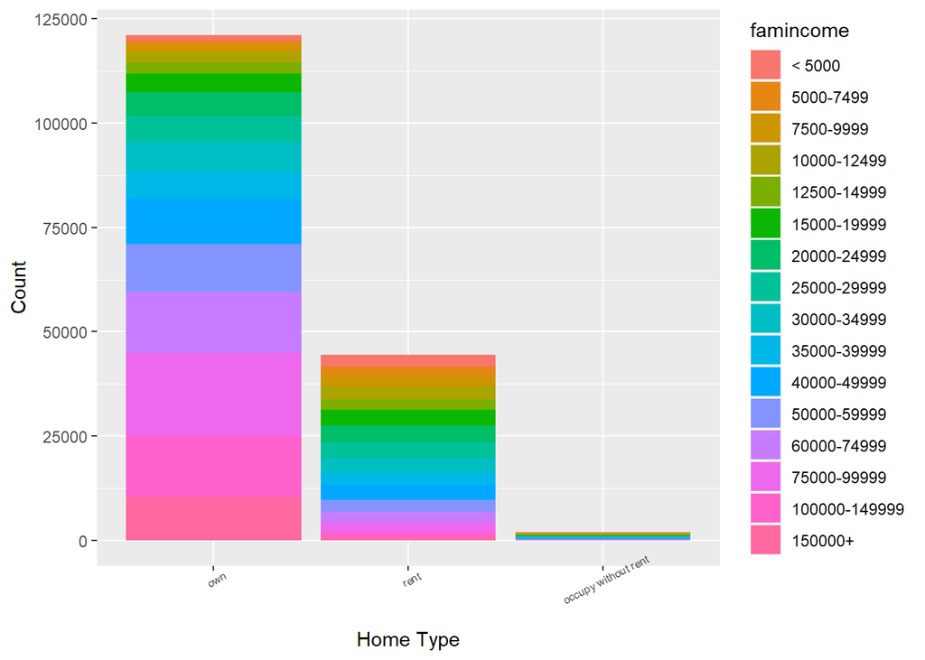

```r
library(ggplot2)
library(RColorBrewer)

plotdps <- ggplot(data=tibble1) +
  geom_bar(mapping=aes(x=home_type, fill=famincome)) +
  xlab("Home Type") +
  ylab("Count") +
  scale_color_brewer("Set1")

plotdps + theme(axis.text.x = element_text(angle = 27, size = 6))
```

VISUALIZATION ANALYSIS: Color-coded simple stacked bar charts, using ggplot2, were chosen to visualize the data because this method is useful in comparing the total amounts across each segmented group. Additionally, stacked bar charts have the advantages of being able to easily view the data and identify potential outliers.

When considering the relationship between the type of home (own, rent, occupy without rent) and family income, the two stacked bar charts visualize the following. No matter what family income range one falls under, there seems to be worth and demand in owning a house. This means even within a humble, lower family income range, there are still home-owners present. This offers the potentially interesting finding that people of lower socioeconomic classes are still trying to chase “the American Dream” or stability, despite renting being a more feasible option for their financial situation. It must be said of course, that this idea is not generalizable to that socioeconomic class as a whole because as both stacked bar charts suggest visually, for lower socioeconomic classes, the renter population still remains more popular than the homeowner population. On the contrary, we see that in the middle to higher income brackets, there are certainly a much larger count of homeowners compared to its opposing category, renters.

```r
library(atus)
chart = table(atuscps$famincome, atuscps$home_type)
chart
```

```
##
##                   own  rent occupy without rent
##   < 5000         1291  2718                 249
##   5000-7499      1171  2196                 102
##   7500-9999      1614  2666                 132
##   10000-12499    2588  3097                 156
##   12500-14999    2614  2492                 108
##   15000-19999    4451  3766                 154
##   20000-24999    5771  4086                 157
##   25000-29999    6269  3783                 170
##   30000-34999    6850  3484                 117
##   35000-39999    6547  2747                 134
##   40000-49999   11020  3734                 156
##   50000-59999   11462  2755                 106
##   60000-74999   14442  2621                  87
##   75000-99999   20041  2360                  86
##   100000-149999 14486  1212                  52
##   150000+       10483   698                  20
```

```r
chisq.test(chart)
```

```
##
##  Pearson's Chi-squared test
##
## data:  chart
## X-squared = 26953, df = 30, p-value < 2.2e-16
```

RELATIONSHIP SIGNIFICANCE ANALYSIS (Pearson’s Chi-Squared Test): As the p-value (<2.2e-16) is less than the .05 significance level, and the chi-squared value is notably large (26953), we reject the null hypothesis and conclude that the two variables, family income and home type (own, rent, occupy without rent), are in fact dependent and have a significant relationship.

[figure not shown]

```r
library(tidyr)
library(dplyr)
library(ggplot2)
library(RColorBrewer)
library(atus)

atus2 <- cbind(atuscps, atusresp)
atusresp$hh_size <- as.character(as.numeric(atusresp$hh_size))

atus3 <- atus2 %>%
  select(famincome, hh_size)

atus4 <- as_tibble(atus3)

chart1 <- ggplot(data=atus4) +
  geom_bar(mapping=aes(x=famincome, fill=hh_size)) +
  xlab("Family Income") +
  ylab("Count") +
  scale_color_brewer("Set1")

chart1 + theme(axis.text.x = element_text(angle = 27, size = 6))
```

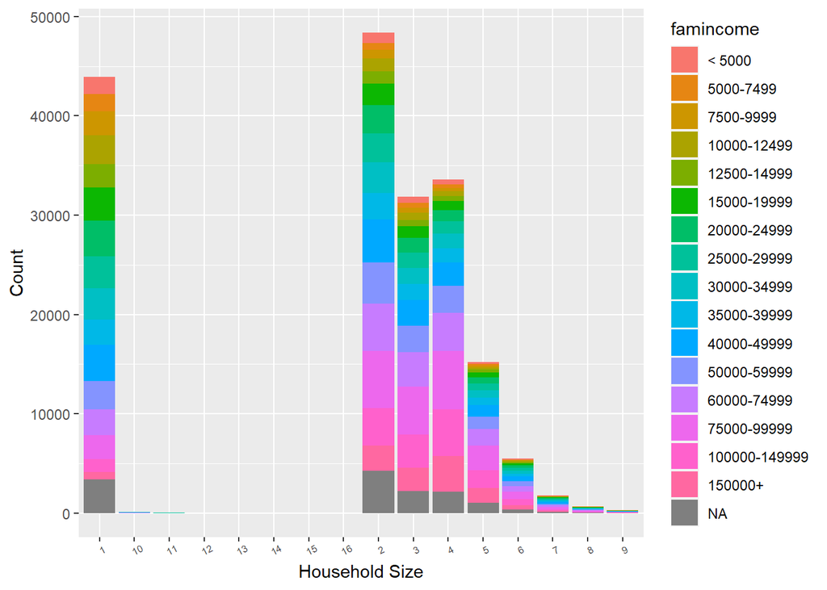

```r
library(tidyr)
library(dplyr)
library(ggplot2)
library(RColorBrewer)
library(atus)

atus2 <- cbind(atuscps, atusresp)
atusresp$hh_size <- as.character(as.numeric(atusresp$hh_size))

atus3 <- atus2 %>%
  select(famincome, hh_size)

atus4 <- as_tibble(atus3)

chart14 <- ggplot(data=atus4) +
  geom_bar(mapping=aes(x=hh_size, fill=famincome)) +
  xlab("Household Size") +
  ylab("Count") +
  scale_color_brewer("Set1")

chart14 + theme(axis.text.x = element_text(angle = 27, size = 6))
```

```r
library(atus)
chart2 = table(atuscps$famincome, atusresp$hh_size)
chart2
```

```
##
##                    1   10   11   12   13   14   15   16    2    3    4    5
##   < 5000        1763    2    0    0    0    0    0    0 1010  654  478  217
##   5000-7499     1684    3    0    1    0    0    0    0  736  446  336  169
##   7500-9999     2449    2    0    1    1    0    0    0  858  528  311  169
##   10000-12499   2879    4    3    1    0    0    0    0 1302  707  516  234
##   12500-14999   2376    7    2    0    2    0    0    0 1210  653  509  284
##   15000-19999   3317    2    2    1    0    0    0    0 2181 1179  886  506
##   20000-24999   3586    5    3    1    0    0    0    0 2814 1442 1112  634
##   25000-29999   3257    6    3    2    0    0    0    0 2948 1595 1295  671
##   30000-34999   3115    9    1    2    0    0    0    1 3059 1611 1463  730
##   35000-39999   2575   15    3    1    1    0    0    0 2689 1572 1401  715
##   40000-49999   3656   18    2    2    2    1    0    0 4333 2622 2364 1207
##   50000-59999   2804   13    2    0    1    0    0    0 4155 2641 2705 1262
##   60000-74999   2623    9    4    3    0    0    0    0 4719 3448 3869 1654
##   75000-99999   2396    6    4    3    0    1    1    0 5799 4837 5890 2442
##   100000-149999 1309    7    3    2    0    0    0    0 3754 3379 4685 1831
##   150000+        723    8    1    0    1    0    0    0 2519 2299 3577 1492
##
##                    6    7    8    9
##   < 5000          71   49   14    5
##   5000-7499       56   30    7    5
##   7500-9999       75   15    8    2
##   10000-12499    131   42   18    6
##   12500-14999    110   38   17   12
##   15000-19999    185   77   28   12
##   20000-24999    274   88   42   16
##   25000-29999    296   92   41   23
##   30000-34999    296  118   40   18
##   35000-39999    300  106   41   14
##   40000-49999    450  178   61   23
##   50000-59999    509  153   59   27
##   60000-74999    550  186   69   31
##   75000-99999    778  233   85   32
##   100000-149999  578  151   43   26
##   150000+        441  101   36   13
```

```r
chisq.test(chart2)
```

```
##
##  Pearson's Chi-squared test
##
## data:  chart2
## X-squared = 21089, df = 225, p-value < 2.2e-16
```

RELATIONSHIP SIGNFICANCE ANALYSIS (Pearson’s Chi-Squared Test): As the p-value (<2.2e-16) is less than the .05 significance level, and the chi-squared value is notably large (21089), we reject the null hypothesis and conclude that the two variables, family income and household size (1-16), are in fact dependent and have a significant relationship.